# Project 1 - Hello *R* You There

Ryan Cheung

Due Fed 3rd

MAKE SURE YOU READ AND FOLLOW **ALL** INSTRUCTIONS ON THE INSTRUCTION DOCUMENT.

### Load packages

```r
library(tidyverse)
library(datasauRus)
```

### Exercise 1

Based on the help file, how many rows and how many columns does the datasaurus_dozen file have?  
What are the variables included in the data frame?

| **Rows** | **Columns** | **Varibles List** |
| --- | --- | --- |
| 1846 | 3 | dataset, x, y |

### Exercise 2

First, let’s plot the data in the dino dataset:

> Ryan’s Notes: Filter for data matching “dino” using dataset datasaurus_dozen, marked with pipe operator.  
> Visualize using ggplot(data,mapping = aes_thetics(x = column_from_data,y = column_from_data) + define_plot_point_shape)

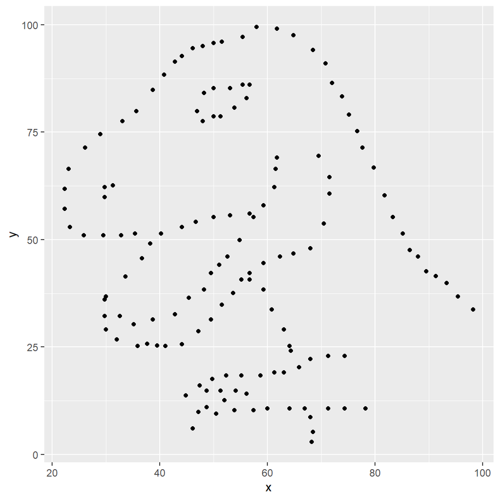

```r
dino_data <- datasaurus_dozen %>%
  filter(dataset == "dino")
ggplot(data = dino_data, mapping = aes(x = x, y = y)) +
  geom_point()
```

And next, calculate the correlation between `x` and `y` in this dataset, then store and display as varible “dino_cor”:

```r
dino_cor <- dino_data %>%
  summarize(r = cor(x, y))
dino_cor
```

```
## # A tibble: 1 x 1
##         r
##     <dbl>
## 1 -0.0645
```

### Exercise 3

Now, let’s plot the ‘star’ data.

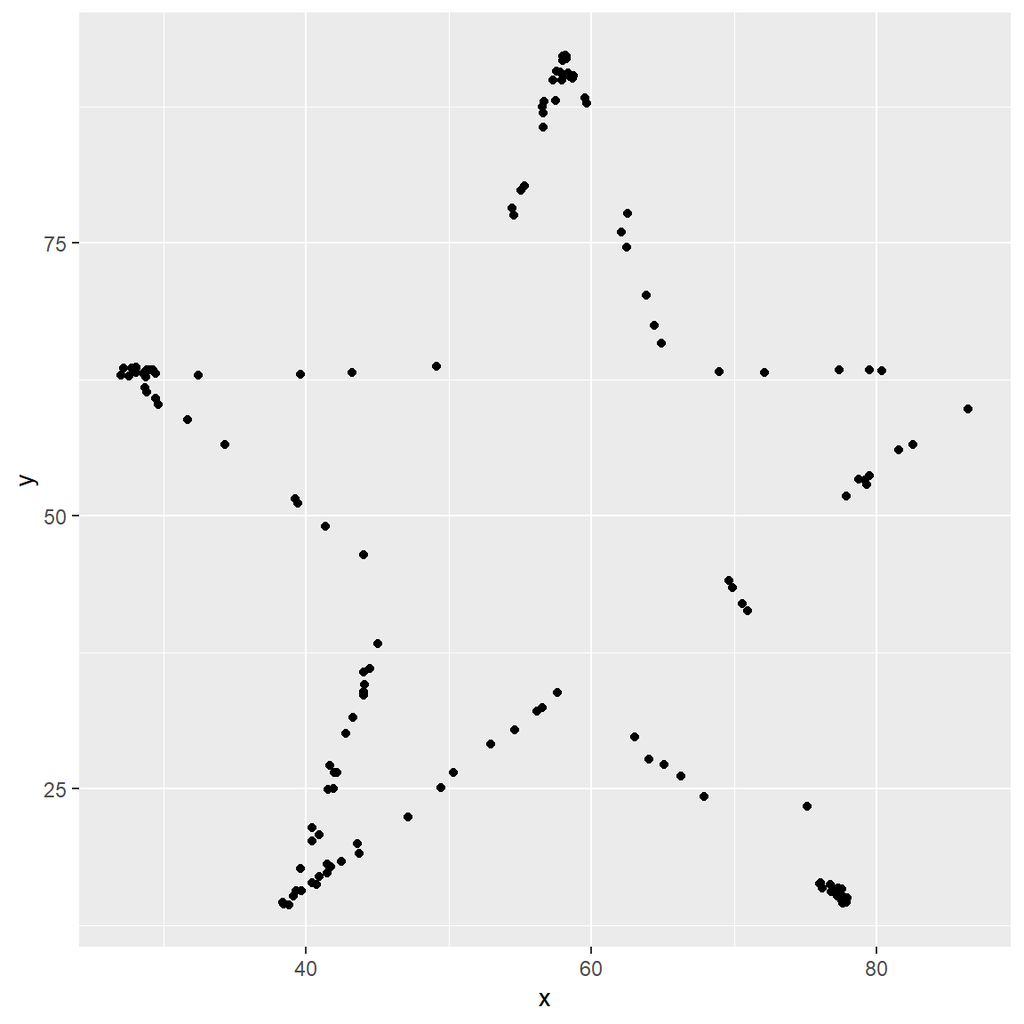

```r
star_data <- datasaurus_dozen %>%
  filter(dataset == "star")
ggplot(data = star_data, mapping = aes(x = x, y = y)) +
  geom_point()
```

And also calculate the correlation coefficient between x and y in the ‘star’ data, then store and display as variable “star_cor”.

```r
star_cor <- star_data %>%
  summarize(r = cor(x, y))
star_cor
```

```
## # A tibble: 1 x 1
##         r
##     <dbl>
## 1 -0.0630
```

The correlation values from dino_data (-0.06447185) and star_data (-0.0629611) are very similar, around 2.343% difference.

```r
dino_star_diff <- (-0.06447185--0.0629611)/-0.06447185
dino_star_diff
```

```
## [1] 0.02343271
```

### Exercise 4

Next, let’s plot the ‘circle’ data.

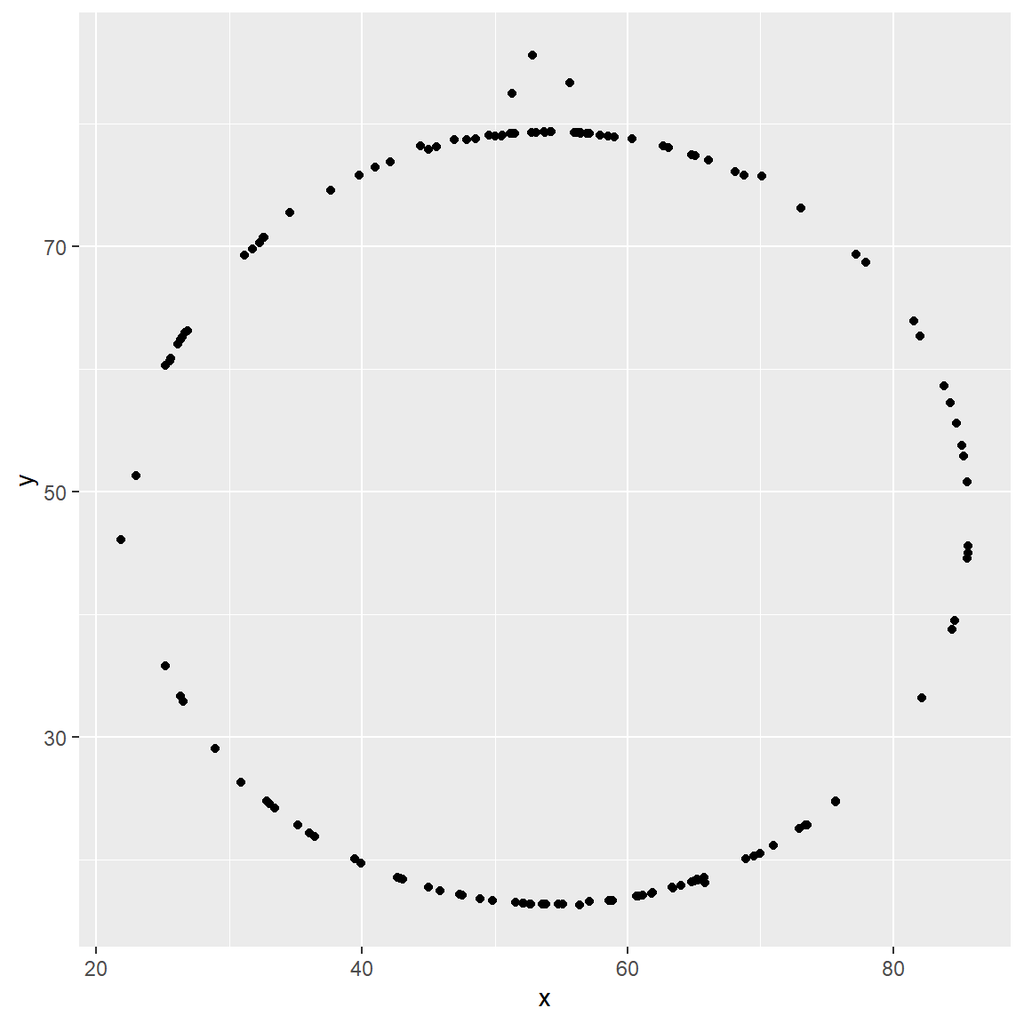

```r
circle_data <- datasaurus_dozen %>%
  filter(dataset == "circle")
ggplot(data = circle_data, mapping = aes(x = x, y = y)) +
  geom_point()
```

And also calculate the correlation coefficient between x and y in the ‘circle’ data, then store and display as variable “circle_cor”.

```r
circle_cor <- circle_data %>%
  summarize(r = cor(x, y))
circle_cor
```

```
## # A tibble: 1 x 1
##         r
##     <dbl>
## 1 -0.0683
```

The correlation values from dino_data (-0.06447185) and circle_data (-0.06834336) are also similar, but not as similar as the dino/star data; around 6.005% difference.

```r
dino_circle_diff <- (-0.06447185--0.06834336)/-0.06447185
dino_circle_diff
```

```
## [1] -0.06004962
```

### Exercise 5

Finally, let’s plot all datasets at once and calculate their summary correlation coefficients. In order to do this we will make use of *facetting*.

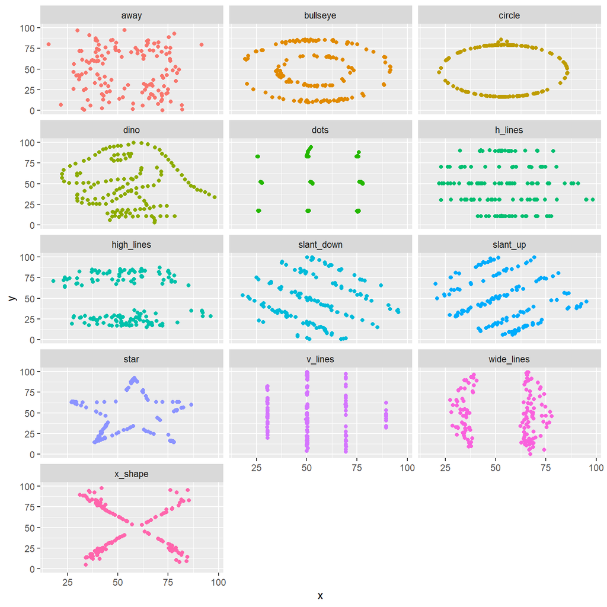

```r
ggplot(datasaurus_dozen, aes(x = x, y = y, color = dataset))+
geom_point()+
facet_wrap(~ dataset, ncol = 3) + # facet the dataset variable, in 3 cols
theme(legend.position = "none")
```

And we can use the group_by function to generate all the summary correlation coefficients.

```r
datasaurus_dozen %>%
group_by(dataset) %>%
summarize(r = cor(x, y)) %>%
print(13)
```

```
## # A tibble: 13 x 2
##    dataset          r
##  * <chr>        <dbl>
##  1 away       -0.0641
##  2 bullseye   -0.0686
##  3 circle     -0.0683
##  4 dino       -0.0645
##  5 dots       -0.0603
##  6 h_lines    -0.0617
##  7 high_lines -0.0685
##  8 slant_down -0.0690
##  9 slant_up   -0.0686
## 10 star       -0.0630
## 11 v_lines    -0.0694
## 12 wide_lines -0.0666
## 13 x_shape    -0.0656
```